# Corporate Finance

Lecture 8: Capital Structure in a Perfect Market (II)

Camilo Saldarriaga

Finance Department, ESCP Business School, 2026/2027

## Plan

- Recap from lecture 7
- Ask how much leverage raises the cost of equity: Modigliani-Miller Proposition II
- See why the weighted average cost of capital does not move
- Write the same result with betas, and use it to price projects from comparables
- Dismantle two popular arguments for debt: earnings per share and dilution
- Practice on three exercises

Mostly based on the BDM textbook Chap. 14.3-14.5.

Recap lecture 7

## Recap: the assumptions of MM I

- Modigliani and Miller (1958) work in a **perfect capital market** (Chap. 14.2):
  1. investors and firms trade the same securities at **fair prices**, equal to the present value of their cash flows;
  2. **no taxes**, transaction costs or issuance costs;
  3. **no bankruptcy costs**;
  4. all investors can **borrow and lend without restrictions at the risk-free rate**;
  5. financing changes neither the **cash flows** of the investments nor the **information** about them.
- Remove any one of them and the conclusions below can change.

## Recap: no taxes, so the WACC loses its tax term

- In Lecture 6 the WACC carried a tax term on the debt, because interest is tax deductible:
  $$r_{WACC} = \frac{E}{E+D}\, r^{L}_{E} + \frac{D}{E+D}\, r_{D}\,(1 - \tau_{C})$$
- Assumption 2 sets the corporate tax rate $\tau_{C}$ to zero, so $(1 - \tau_{C}) = 1$ and the term disappears:
  $$r_{WACC} = \frac{E}{E+D}\, r^{L}_{E} + \frac{D}{E+D}\, r_{D}$$
- This is the **pre-tax WACC**: the plain weighted average of what shareholders and lenders require. Debt has no tax advantage here.

## Recap: Tour moche SA with equity only

Invest **800** today; receive **1400** (strong economy) or **900** (weak), each with probability one half. Cost of equity 15%, given (Chap. 14.1).

- With equity only, the cost of capital **is** the cost of equity: 15%.
- Expected cash flow $0.5 \times 1400 + 0.5 \times 900 = 1150$.
- Value of the firm $= 1150 / 1.15 = 1000$. NPV $= -800 + 1000 = 200$.
- The entrepreneur sells the whole equity for 1000, pays the 800 and keeps the 200. This equity is called **unlevered equity**; by construction its shareholders earn 15% on average.

## Recap: the same project with 500 of debt, step by step

- **Step 1, the lenders.** The firm borrows 500 at the risk-free 5%. Next year it owes $500 \times 1.05 = 525$ in both states.
- **Step 2, the shareholders.** Lenders are paid first; shareholders take what is left: $1400 - 525 = 875$ or $900 - 525 = 375$. This is **levered equity**.
- **Step 3, add them up.** $525 + 875 = 1400$ and $525 + 375 = 900$: debt and equity together receive **exactly the project’s cash flows**.

  | Levered firm | Year 0 | Strong | Weak |
  | --- | --- | --- | --- |
  | Debt | 500 | 525 | 525 |
  | Levered equity | ? | 875 | 375 |
  | Firm | ? | **1400** | **900** |

## Recap: step by step (con’t)

- **Step 4, the law of one price.** Two investments that pay the same cash flows in every state must sell for the same price. Debt plus equity pays what the unlevered firm pays, so the levered firm is also worth **1000**.
- **Step 5, the equity.** $E = 1000 - 500 = 500$.

  | Levered firm | Year 0 | Strong | Weak |
  | --- | --- | --- | --- |
  | Debt | 500 | 525 | 525 |
  | Levered equity | **500** | 875 | 375 |
  | Firm | **1000** | 1400 | 900 |

- **Step 6, the entrepreneur.** She raises $500 + 500 = 1000$ either way, pays 800 and keeps 200 either way.

Changing the capital structure did not change the size of the pie.

## The fallacy: discount the levered equity at the same rate

- Levered equity pays $0.5 \times 875 + 0.5 \times 375 = 625$ on average. Discounting at the unlevered 15% gives $625 / 1.15 = 543$, more than 500. **Wrong**: the discount rate changed.
- Shareholders pay 500 and receive 875 or 375: returns $+75\%$ or $-25\%$, **25%** expected, the cost of equity increased due to the risk. And $625 / 1.25 = 500$.

  | Debt | Equity | $r^{L}_{E}$ | Average cost of capital |
  | --- | --- | --- | --- |
  | 0 | 1000 | 15% | 15% |
  | 500 | 500 | 25% | $0.5 \times 5\% + 0.5 \times 25\% = 15\%$ |

Debt is cheaper, but equity gets more expensive.

## Recap: MM Proposition I

**MM Proposition I.** In a perfect capital market, the total value of a firm’s securities equals the market value of the cash flows generated by its assets, and is not affected by its choice of capital structure.

- **Why.** Everything the assets produce goes to the security holders. Same total cash flows, so same total value, whatever the slices.
- Miller’s pizza: Yogi Berra asks for eight slices instead of four because he is hungry. Cutting the pizza differently does not make more pizza.

## Recap: homemade leverage

- Investors can build the leverage they want **themselves**, as long as they borrow at the same rate as the firm.
- **More leverage**: borrow 500 and buy the unlevered firm. Same payoffs as levered equity, for 500.

  | Portfolio | Year 0 | Strong | Weak |
  | --- | --- | --- | --- |
  | Buy unlevered equity | $-1000$ | $+1400$ | $+900$ |
  | Borrow 500 | $+500$ | $-525$ | $-525$ |
  | **Total** | **$-500$** | **$+875$** | **$+375$** |

- **Less leverage**: buy the levered firm’s debt **and** equity, $500 + 500$. The debt you own cancels the firm’s debt: payoffs 1400 or 900, like unlevered equity, for 1000.

## Recap: homemade leverage proves MM I

- Firms **U** (no debt, worth $V_U$) and **L** (debt 500, equity $E_L$) have the same assets. Suppose their prices differ.
- **U too expensive** (1050 against 1000). Sell U, buy L’s debt and shares:

  | Trade | Year 0 | Strong | Weak |
  | --- | --- | --- | --- |
  | Sell U’s shares | $+1050$ | $-1400$ | $-900$ |
  | Buy L’s debt | $-500$ | $+525$ | $+525$ |
  | Buy L’s shares | $-500$ | $+875$ | $+375$ |
  | **Total** | **$+50$** | **$0$** | **$0$** |

- **U too cheap** (990 against $500 + 510$). Sell L’s shares, borrow 500, buy U: $+20$ today, $0$ next year in both states.

Free money today, nothing changed tomorrow: everyone trades until $V_U = V_L$. The **law of one price** makes MM I hold.

## Recap: the market value balance sheet

By MM I, the market value of the firm’s assets equals the market value of the securities it has issued:
$$\text{Equity} = \text{Assets} - \text{Debt and other liabilities}$$

- Unlike the accounting balance sheet, **every** asset counts, including intangibles, and all at **market value**.
- Attention: the market value of an asset is often hard, or impossible, to pin down.

## Recap: the unlevered cost of capital (L6)

The assets are owned by shareholders and lenders together, so their expected return is the **weighted average** of what each group earns (Chap. 12.5):
$$r^{U}_{E} = \frac{E}{E+D}\, r^{L}_{E} + \frac{D}{E+D}\, r_{D}
\qquad\qquad
\beta^{U}_{E} = \frac{E}{E+D}\, \beta^{L}_{E} + \frac{D}{E+D}\, \beta_{D}$$

- $E$, $D$: market values of equity and debt. $r^{L}_{E}$, $r_{D}$: the costs of capital of the **levered** firm’s equity and debt. $r^{U}_{E}$: the cost of **unlevered** equity, the return of the business itself (Lecture 6 wrote it $r_{U}$).
- Notation from now on: superscript $L$ for the levered firm, $U$ for the unlevered one.

Beginning of lecture 8 content

Lecture 7 showed that leverage does not change what the firm is worth. But debt costs 5% and equity 15%, so how can the average not fall? Because the cost of equity rises exactly enough. Today we see by how much.

## Introduction

- **A common argument.** “Debt costs 5%, equity 15%. Replace half of the equity by debt and the average cost of capital drops from 15% to 10%. So why not borrow as much as possible, at least while the debt stays safe?”

Leverage changes the **risk** of equity, and therefore the return shareholders require. Today we put a number on how much, and show that the saving on cheap debt is given back, cent for cent, through more expensive equity.

## Outline

1. MM Proposition II: leverage and the cost of equity (Chap. 14.3)
2. The WACC does not move (Chap. 14.3)
3. Levered and unlevered betas (Chap. 14.3)
4. Two fallacies: earnings per share and dilution (Chap. 14.4)
5. Summary: the theorems of Modigliani and Miller (Chap. 14.5)
6. Exercises

## A. MM Proposition II

**MM Proposition II.** The cost of levered equity is the unlevered cost of capital plus a premium that grows with the debt-to-equity ratio:
$$r^{L}_{E} = r^{U}_{E} + \frac{D}{E}\,\big(r^{U}_{E} - r_{D}\big)$$

- The second term is the **price of leverage**. It is zero without debt and grows with every euro of debt per euro of equity.
- Three steps to get there:
  1. write MM Proposition I as an equation;
  2. compute the return of a portfolio of the firm’s debt and equity;
  3. solve for the return of equity.

## Step 1: MM I as an equation

- Let $E$ be the market value of the levered equity, $D$ the market value of the debt, $U$ what the equity would be worth if the firm had no debt, and $A$ the market value of the firm’s assets.
- MM Proposition I says that the securities are worth the assets, with or without leverage:
  $$E + D = U = A$$
- Read the first equality through homemade leverage: holding **both** the debt and the levered equity gives exactly the cash flows of the unlevered equity.

## Step 2: the return of the portfolio

- The return of a portfolio is the weighted average of the returns of what is in it. A portfolio holding all the debt and all the equity has weights $E/(E+D)$ and $D/(E+D)$, and earns the unlevered return:
  $$\frac{E}{E+D}\, R^{L}_{E} + \frac{D}{E+D}\, R_{D} = R^{U}_{E}$$
- $R^{L}_{E}$, $R_{D}$, $R^{U}_{E}$ are the **realised** returns of levered equity, debt and unlevered equity.

## Step 3: solve for the return of equity

- Start from Step 2:
  $$\frac{E}{E+D}\, R^{L}_{E} + \frac{D}{E+D}\, R_{D} = R^{U}_{E}$$
- **(a) Multiply both sides by $(E+D)/E$.** On the left, the fractions simplify:
  $$R^{L}_{E} + \frac{D}{E}\, R_{D} = \frac{E+D}{E}\, R^{U}_{E}$$
- **(b) Split the fraction on the right**, since $(E+D)/E = 1 + D/E$:
  $$R^{L}_{E} + \frac{D}{E}\, R_{D} = R^{U}_{E} + \frac{D}{E}\, R^{U}_{E}$$
- **(c) Subtract $\frac{D}{E} R_{D}$ from both sides**, so $R^{L}_{E}$ is alone on the left:
  $$R^{L}_{E} = R^{U}_{E} + \frac{D}{E}\, R^{U}_{E} - \frac{D}{E}\, R_{D}$$

## Step 3 (con’t): solve for the return of equity

- **(d) Factor out $D/E$** from the last two terms:
  $$R^{L}_{E} = R^{U}_{E} + \frac{D}{E}\,\big(R^{U}_{E} - R_{D}\big)$$
- The return on levered equity is the return without leverage **plus an extra kick**. It is the extra return levered shareholders require because of leverage. The size of the kick is $D/E$.
- Assuming everything constant, what we move with capital structure is the $D/E$.
- The equation holds for realised returns, so it holds for **expected** returns too. Replace $R$ by $r$:

**MM Proposition II**: $\;r^{L}_{E} = r^{U}_{E} + \dfrac{D}{E}\,(r^{U}_{E} - r_{D})$. The cost of levered equity increases with the market-value debt-to-equity ratio.

## Apply it to Tour moche SA: the portfolio of Step 2

- From Lecture 7: debt 500 and levered equity 500, so weights one half each.

  | Security | Today | Strong | Weak | Return strong | Return weak |
  | --- | --- | --- | --- | --- | --- |
  | Debt | 500 | 525 | 525 | $+5\%$ | $+5\%$ |
  | Equity | 500 | 875 | 375 | $+75\%$ | $-25\%$ |
  | **Portfolio** | **1000** | **1400** | **900** | **$+40\%$** | **$-10\%$** |

- The portfolio return is the weighted average of the two rows above it:
  - strong economy: $0.5 \times 5\% + 0.5 \times 75\% = 40\%$
  - weak economy: $0.5 \times 5\% + 0.5 \times (-25\%) = -10\%$
- $+40\%$ / $-10\%$ are the returns of the **unlevered** equity in Lecture 7 (pay 1000, receive 1400 or 900). Step 2 holds with real numbers.

## Apply it to Tour moche SA (con’t): MM II

- Unlevered cost of capital $r^{U}_{E} = 15\%$, debt cost $r_{D} = 5\%$.

  | Debt $D$ | Equity $E$ | $D/E$ | $r^{L}_{E} = r^{U}_{E} + \frac{D}{E}(r^{U}_{E} - r_{D})$ |
  | --- | --- | --- | --- |
  | 500 | 500 | 1 | $15\% + 1 \times (15\% - 5\%) = 25\%$ |
  | 200 | 800 | 0.25 | $15\% + 0.25 \times (15\% - 5\%) = 17.5\%$ |

- The formula also says what happens at **any** level of debt: with 750 of debt ($D/E = 3$), $r^{L}_{E} = 15\% + 3 \times 10\% = 45\%$.

## B. The WACC does not move.

In a perfect market the weighted average cost of capital is the unlevered cost of capital, whatever the mix:
$$r_{WACC} = \frac{E}{E+D}\, r^{L}_{E} + \frac{D}{E+D}\, r_{D} = r^{U}_{E}$$

- If the WACC is the same no matter the capital structure, we can take the simplest case as baseline value: 100% equity.
- Consequence: We can use the WACC as discount rate with any capital structure. The cash flows do not depend on financing, and neither does the WACC, so **neither does the value of the firm**. That is MM I again.

## The WACC at four debt levels

- The entrepreneur’s project with more and more debt (Figure 14.1b):

  | $E$ | $D$ | $r^{L}_{E}$ | $r_{D}$ | $r_{WACC} = \frac{E}{E+D} r^{L}_{E} + \frac{D}{E+D} r_{D}$ |
  | --- | --- | --- | --- | --- |
  | 1000 | 0 | 15.0% | 5.0% | $1.0 \times 15\% + 0 \times 5\% = 15\%$ |
  | 800 | 200 | 17.5% | 5.0% | $0.8 \times 17.5\% + 0.2 \times 5\% = 15\%$ |
  | 500 | 500 | 25.0% | 5.0% | $0.5 \times 25\% + 0.5 \times 5\% = 15\%$ |
  | 100 | 900 | 75.0% | 8.3%$^*$ | $0.1 \times 75\% + 0.9 \times 8.3\% = 15\%$ |

- The cost of equity climbs steeply, but more weight goes on the cheap source: the average stays at **15%**.

$^*$ With 900 of debt the firm defaults in the weak state: lenders are promised 16.67% but expect 8.33%.

## The WACC in a picture

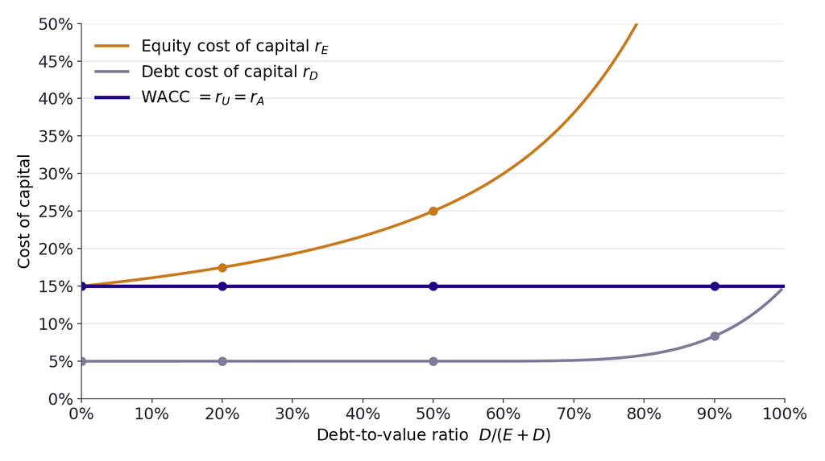

## Example: NRG reduces its leverage

- **Example.** NRG Energy has a debt-to-equity ratio of 2, a debt cost of 6% and an equity cost of 12%. With $D/E = 2$, debt is two thirds of the firm and equity one third.
- **Unlevered cost of capital** (and WACC):
  $$r^{U}_{E} = \tfrac{1}{3} \times 12\% + \tfrac{2}{3} \times 6\% = 8\%.$$
- NRG issues equity to repay debt until $D/E = 1$. Safer debt now costs 5.5%. **New cost of equity**: $r^{L}_{E} = 8\% + 1 \times (8\% - 5.5\%) = 10.5\%$.
- **New WACC**: $0.5 \times 10.5\% + 0.5 \times 5.5\% = 8\%$. Unchanged.
- If NRG repaid all its debt, its equity would cost $r^{U}_{E} = 8\%$: the WACC again.

Less leverage: cheaper equity, dearer average? No. The WACC, the cash flows and therefore the **enterprise value** are the same in all three cases.

## C. Capital structure and betas

- We saw that the WACC does not change with the capital structure. The cost of equity increases but it is compensated by a greater share of cheaper debt. For the betas it is the same.
- Beta is a measure of risk exposure. Changing the capital structure moves risk between lenders and shareholders, it does not create or destroy it.
- So the firm betas don’t change with capital structure, what changes is the equity beta.

## C. Equity beta: levered and unlevered.

Unlevered Betas follow the same formula:
$$\beta^{U}_{E} = \frac{E}{E+D}\, \beta^{L}_{E} + \frac{D}{E+D}\, \beta_{D}
\qquad\qquad
\beta^{L}_{E} = \beta^{U}_{E} + \frac{D}{E}\,\big(\beta^{U}_{E} - \beta_{D}\big)$$

- $\beta^{U}_{E}$ is the **unlevered** (or asset) beta: the market risk of the business, as if it had no debt. $\beta^{L}_{E}$ is the **levered** (or equity) beta: business risk plus the risk added by leverage. $\beta_{D}$ is the debt beta.
- Why the same rule? The beta of a portfolio is the weighted average of the betas in it, and the portfolio of all the firm’s securities has the risk of the assets.

## Beta and leverage: deriving the formula

- **Step 1.** Hold all the debt and all the equity of the levered firm. This portfolio receives every cash flow of the assets, so it has the same risk as the **unlevered** firm: the two betas are equal.
- **Step 2.** The beta of a portfolio is the weighted average of the betas of what is in it (Lecture 4). The weights are the shares of debt and equity in the firm’s value:
  $$\beta^{U}_{E} = \beta^{\text{Portfolio}}_{D+E}
  = \frac{D}{D+E}\, \beta_{D} + \frac{E}{D+E}\, \beta^{L}_{E}$$
- This is the first formula of the box. Next slide: solve it for the stock beta to get the second one.

## Beta and leverage: deriving the formula (con’t)

- **Step 3.** Solve for the stock beta $\beta^{L}_{E}$.
  - **(a)** Multiply both sides by $(D+E)$: $(D+E)\, \beta^{U}_{E} = D\, \beta_{D} + E\, \beta^{L}_{E}$
  - **(b)** Move the debt term to the left and divide by $E$:
    $$\beta^{L}_{E} = \frac{(D+E)\, \beta^{U}_{E} - D\, \beta_{D}}{E}$$
  - **(c)** Split the fraction, using $(D+E)/E = 1 + D/E$:
    $$\beta^{L}_{E} = \beta^{U}_{E} + \frac{D}{E}\,\big(\beta^{U}_{E} - \beta_{D}\big)$$
- In words: the equity carries the business risk, minus the part the lenders take, spread over the euros of equity alone.

## If the debt is risk free

- With risk-free debt, $\beta_{D} = 0$ and the second formula simplifies to:

$$\beta^{L}_{E} = \beta^{U}_{E} \times \frac{E + D}{E} = \beta^{U}_{E}\,\Big(1 + \frac{D}{E}\Big)$$

- Intuition: each euro of equity controls $(E+D)/E$ euros of assets, and carries that many times the business risk.
- **Example.** A firm with a debt-to-equity ratio of 2 has an equity beta of 1.7 and risk-free debt. What is its asset beta? Next slide, step by step.

## Example: from the equity beta to the asset beta

- **What we know.** The stock’s beta $\beta^{L}_{E} = 1.7$, the ratio $D/E = 2$, and the debt is risk free, so $\beta_{D} = 0$.
- **What we want.** The asset beta $\beta^{U}_{E}$: the risk of the business as if it had no debt.
- **Step 1.** With risk-free debt the formula is
  $$\beta^{L}_{E} = \beta^{U}_{E}\,\Big(1 + \frac{D}{E}\Big)$$
- **Step 2.** Put in the numbers: $1.7 = \beta^{U}_{E} \times (1 + 2) = 3 \times \beta^{U}_{E}$.
- **Step 3.** Solve for the unknown: $\beta^{U}_{E} = 1.7 / 3 = 0.57$.
- **Reading.** Each euro of equity controls 3 euros of assets, so the stock is three times as risky as the business. Strip the leverage and 1.7 becomes 0.57.

## Example (con’t): back to an equity beta

- **Question.** A firm in the same industry has a debt ratio $D/(D+E) = 0.5$. What is the beta of its stock? (Same business, so same asset beta 0.57.)
- **Step 1. Convert the debt ratio into $D/E$.** Debt is half of the firm, so debt equals equity: $D = E$ and $D/E = 1$.
- **Step 2.** Same formula, now solving for the stock beta:
  $$\beta^{L}_{E} = \beta^{U}_{E}\,\Big(1 + \frac{D}{E}\Big) = 0.57 \times (1 + 1) = 1.13$$
- **Reading.** This firm has less leverage than the first one ($D/E = 1$ instead of 2), so its stock is less risky: 1.13 instead of 1.7. It is still riskier than the business itself (0.57), because it does carry some debt.
- This two-way use of the formula, **unlever** then **relever**, is exactly what we do next for a whole industry.

## Example: CVS raises its leverage

- **Example** The drug retailer CVS has an equity beta of 0.8 and a debt-to-equity ratio of 0.1. Its debt beta is zero.
- CVS plans to borrow more, raising its debt-to-equity ratio from 0.1 to 0.5, without changing its business and keeping its debt risk free. What will its equity beta be after the change?
- Two steps: first **unlever** the current beta to find the beta of the business, then **relever** it at the new debt-to-equity ratio.

## Example: CVS raises its leverage (con’t)

- **Unlever.** The formula needs the shares of equity and debt in the firm’s value, $E/(E+D)$ and $D/(E+D)$, but we only know $D/E = 0.1$.
- **The trick** is to measure everything in units of equity. If $D/E = 0.1$, then for every 1 of equity there is 0.1 of debt, so the firm is worth $1 + 0.1 = 1.1$ in those units. Then:
  - equity share: $E/(E+D) = 1 / 1.1 = 0.909$
  - debt share: $D/(E+D) = 0.1 / 1.1 = 0.091$
- Now apply the formula:
  $$\beta^{U}_{E} = \frac{1}{1.1} \times 0.8 + \frac{0.1}{1.1} \times 0 = 0.73.$$

## Example: CVS raises its leverage (con’t 2)

- CVS borrows until $D/E = 0.5$, with the debt still risk free. **Relever**, using the second formula, which takes $D/E$ directly:
  $$\beta^{L}_{E} = 0.73 + 0.5 \times (0.73 - 0) = 1.09.$$
- The equity beta, and with it the cost of equity, rises with leverage.

## Cash as negative debt

- Cash and risk-free securities on the balance sheet are the opposite of leverage: they make the equity **safer** than the business. Measure leverage with **net debt** $=$ debt $-$ cash.
- **Example** Cisco, March 2022: market capitalisation 230 billion, debt 12 billion, cash 25 billion, equity beta 0.95, debt beta about zero. Risk-free rate 2.75%, market risk premium 5%.
- **Question.** What is the cost of capital of Cisco’s **business**, the unlevered cost of capital we would use to evaluate one of its projects?
- **Plan.** Find the net debt, then the value of the business, then unlever the equity beta with net debt in place of $D$, then apply the CAPM.

## Cash as negative debt (con’t)

- **Step 1, net debt.** $12 - 25 = -13$ billion: Cisco holds more cash than debt, so its net debt is negative.
- **Step 2, value of the business.** Equity plus net debt: $230 - 13 = 217$ billion (the enterprise value).
- **Step 3, unlever.** Same formula as before, with net debt in place of $D$:
  $$\beta^{U}_{E} = \frac{230}{217} \times 0.95 + \frac{-13}{217} \times 0 = 1.01.$$
- **Step 4, the CAPM.** Cost of capital of the business: $2.75\% + 1.01 \times 5\% = 7.8\%$.
- **Reading.** The business beta (1.01) is **above** the equity beta (0.95): because of its cash, Cisco’s shares are **less** risky than its business. Cash dilutes the business risk the way debt concentrates it.

## The cost of capital of an industry

- Industry average betas are often used, because the firm is not listed or because an average over several firms is a better estimate than one beta.
- **Attention:** firms in the same industry have different leverage. Average the **unlevered** betas, never the equity betas.
- Steps:
  1. Identify a sample of comparable firms.
  2. For each, find the equity beta, the debt-to-equity ratio and, if possible, the debt beta.
  3. Unlever each firm’s beta.
  4. Average the unlevered betas.
  5. Relever the average to the target firm’s own debt-to-equity ratio.

## Beta of an industry: example

- Four listed firms in the same industry, all with risk-free debt:

  | Firm | Equity beta | $D/E$ | Asset beta $= \beta^{L}_{E} / (1 + D/E)$ |
  | --- | --- | --- | --- |
  | A | 1.1 | 23.31% | 0.892 |
  | B | 1.3 | 44.35% | 0.901 |
  | C | 1.3 | 2.15% | 1.273 |
  | D | 0.8 | 3.03% | 0.776 |
  | Average |  |  | **0.960** |

- Firm P is not listed, operates in the same industry and has $D/E = 0.2$. What is its equity beta?
- Relever the average: $\beta^{L}_{E} = 0.960 \times (1 + 0.2) = 1.15$.

## D. Capital structure fallacies

- MM1 framework: the capital structure does not affect the value of the firm.
- But, even in this framework, wrong arguments are used to argue in favor of using leverage:
  1. Leverage and Earnings per Share
  2. Equity issuance and dilution

## Leverage and EPS

- Leverage can increase expected Earnings per Share (EPS).
  - Some stockholders therefore conclude that leverage should increase the stock price.
- However, the risk of earnings also changes and the average increase of EPS is necessary to compensate shareholders.
- In perfect capital markets, the price should not change!

## Equity issuance and dilution

- Dilution: an increase in the total of shares that will divide a fixed amount of earnings.
- An increase in capital usually dilutes the EPS.
- It is sometimes (incorrectly) argued that issuing equity will dilute existing shareholders’ ownership, so debt financing should be used instead.
- In fact: no dilution of value if the stocks are sold at their market value.
  - Any gain or loss associated with the transaction will result from the NPV of the investments the firm makes with the funds raised.
  - The decrease in stock price which is often observed at the announcement of an increase in capital corresponds to an information effect (thus: it is related to market frictions).

## E. Summary: Modigliani-Miller theorems

- Perfect capital markets $\Rightarrow$ Conservation of value
  - Financial transactions neither add nor destroy value, but instead represent a repackaging of risk (and therefore return).
  - **The cost of capital depends on the assets of the firm and their risk.**
- Modigliani-Miller for dummies:
  - The total amount of pizza does not change if you slice it up differently!
- Practical implications:
  - Investment decisions are more important than financing decisions.
  - It is easier to create or destroy value with investment decisions than with financing decisions.

## F. Exercise 1: cost of capital and leverage

- Amalgamated Products (Am.Pr.) owns three activities: Food (40% of the value of the firm), Electronics (30%) and Chemicals (30%).
- Amalgamated Products doesn’t pay tax. To estimate its cost of capital Amalgamated has identified three competitors:

  |  | Beta of the stock | Debt/(Debt+Equity) |
  | --- | --- | --- |
  | United Foods | 0.8 | 0.4 |
  | General Electronics | 1.6 | 0.2 |
  | Associated Chemicals | 1.2 | 0.3 |

- We assume that the debt of the firm is risk-free.
  1. What are the asset betas of each division of Amalgamated?
  2. The debt ratio of Amalgamated is D/(D+E)=0.4. What is the beta of the stock of Amalgamated?
  3. With $r_f=7\%$ and $r_M= 15\%$, what is the cost of capital of each division?
  4. What is the WACC of Amalgamated?

## Exercise 1: answer (a)

- **(a) Asset betas.** The debt is risk free, so each competitor’s asset beta is its stock beta times the equity share of the firm, $E/(D+E) = 1 - D/(D+E)$.
- Step 1, the equity share of each comparable: Foods $1 - 0.4 = 0.6$, Electronics $1 - 0.2 = 0.8$, Chemicals $1 - 0.3 = 0.7$.
- Step 2, apply the formula, equity share times stock beta plus debt share times the debt beta of zero:

  | Division | Stock beta | Asset beta |
  | --- | --- | --- |
  | Food | 0.8 | $0.6 \times 0.8 + 0.4 \times 0 = 0.48$ |
  | Electronics | 1.6 | $0.8 \times 1.6 + 0.2 \times 0 = 1.28$ |
  | Chemicals | 1.2 | $0.7 \times 1.2 + 0.3 \times 0 = 0.84$ |

- Each division of Amalgamated gets the asset beta of its comparable: same business, same business risk.

## Exercise 1: answer (b)

- **(b) Stock beta of Amalgamated.**
- Step 1, the asset beta of the whole firm is the average of the division betas, weighted by their share of the value:
  $$\beta^{U}_{E} = 0.4 \times 0.48 + 0.3 \times 1.28 + 0.3 \times 0.84 = 0.828$$
- Step 2, relever. With $D/(D+E) = 0.4$, equity is $0.6$ of the firm, so
  $$\beta^{L}_{E} = \beta^{U}_{E} \times \frac{D+E}{E} = \frac{0.828}{0.6} = 1.38$$
- Reading: the stock is riskier than the businesses it owns (1.38 against 0.828), because 40% of the firm is financed with debt that carries no risk.

## Exercise 1: answer (c) and (d)

- **(c) Cost of capital of each division.** The CAPM with the **asset** beta, because a division is a business, not a stock. Market premium $r_{M} - r_{f} = 15\% - 7\% = 8\%$:

  | Division | $\beta^{U}_{E}$ | $r = 7\% + \beta^{U}_{E} \times 8\%$ |
  | --- | --- | --- |
  | Food | 0.48 | $7\% + 0.48 \times 8\% = 10.84\%$ |
  | Electronics | 1.28 | $7\% + 1.28 \times 8\% = 17.24\%$ |
  | Chemicals | 0.84 | $7\% + 0.84 \times 8\% = 13.72\%$ |

- **(d) WACC of Amalgamated.** Without taxes the WACC is the unlevered cost of capital, so use the firm’s asset beta from (b):
  $$r_{WACC} = r^{U}_{E} = 7\% + 0.828 \times 8\% = 13.62\%$$
- Check by the long route: cost of equity $7\% + 1.38 \times 8\% = 18.04\%$, debt at $r_{f} = 7\%$, weights 0.6 and 0.4: $0.6 \times 18.04\% + 0.4 \times 7\% = 13.62\%$. Same number, as MM says.

## Exercise 2: reducing leverage

- Infonian AG is a very leveraged firm with a debt to equity ratio of 150%. The bank does not consider the debt as risky and asks for an interest rate of 5% ($\approx r_f$). The equity holders require a return of 20%. The company does not pay tax.
  - What is the WACC of the firm?
  - What is the cost of equity if Infonian issues equity and reduces its debt to achieve a debt to equity ratio of 50%?

## Exercise 2: answer

- **Step 1, the weights.** $D/E = 1.5$ means 1.5 of debt for every 1 of equity, so the firm is worth 2.5 in those units: debt is $1.5/2.5 = 0.6$ of the firm and equity $1/2.5 = 0.4$.
- **Step 2, the WACC.** No taxes, so the plain weighted average:
  $$r_{WACC} = 0.4 \times 20\% + 0.6 \times 5\% = 8\% + 3\% = 11\%$$
- **Step 3, what stays and what moves.** Issuing equity to repay debt does not change the assets, so the WACC stays at 11% (MM I). It is the cost of equity that falls, by MM II.
- **Step 4, the new cost of equity** at $D/E = 0.5$:
  $$r^{L}_{E} = r^{U}_{E} + \frac{D}{E}\,(r^{U}_{E} - r_{D})
  = 11\% + 0.5 \times (11\% - 5\%) = 14\%$$
- **Check.** New weights: equity $1/1.5 = 2/3$, debt $1/3$. WACC $= \tfrac{2}{3} \times 14\% + \tfrac{1}{3} \times 5\% = 11\%$. Unchanged.

## Exercise 3: increasing leverage

- Mr. Goodman the CFO of Perkscom comes back thoughtful from the shareholder meeting of his firm. The investment fund who owns 10% of the capital of Perkscom has announced to the CFO Mr. Goodman at the annual shareholder meeting that it expects an **earnings yield** of at least 20% for the current year, otherwise it would take away the stock options for the managers of the firm. Because Mr. Goodman counts on his stock options to repay the mortgage for his villa, he is a bit worried and thinks about what he can do.
- The cash flow of Perkscom is equal to the EBIT of 10 million for this year with annual growth rate of 10% per year. The firm has no leverage. The accounting value of its equity is 80 million and its stock market capitalisation is 100 million.
- The firm could easily raise debt at an interest rate of 5%. Perkscom does not pay tax (tax rate = 0) and distributes all its cash flows as dividends to shareholders.

## Exercise 3: increasing leverage (con’t)

1. If the market anticipates the perpetual growth rate of the EBIT of 10%, what should be the cost of capital of Perkscom?
2. Suppose that with a more efficient reorganisation of its production, Perkscom can increase its cash flows by 50% from 10 million to 15 million at the end of the year with the same perpetual growth rate as previously. What is now the value of the firm and the return on equity and earnings yield?
3. Mr. Goodman understands that with operational measures, he cannot achieve the earnings yield required by the investment fund. He decides to increase the leverage to the debt-to-equity ratio of 3:1 without changing the assets of the company (e.g., we are in the initial setting and not the one of 2.) and without increasing the cashflows of the company. Compute the amount of debt to be raised and describe briefly the necessary transactions.

## Exercise 3: increasing leverage (con’t 2)

4. What will be the WACC after the transaction and what will be the cost of equity?
5. What will the earnings yield and return on equity be?
6. What is the lowest level of leverage that can achieve the earnings yield required by the investment fund?
7. Has the investment fund chosen a good performance measure? Should it be satisfied by the measures taken by Mr. Goodman?

## Exercise 3: the earnings yield

- The investment fund asks for an **earnings yield** of at least 20%, twice the current one, as we will see. First, what is that ratio?

$$\text{Earnings yield} = \frac{\text{Earnings}}{\text{Market value of equity}}$$

- **Perkscom today.** Earnings are the EBIT, 10 million: no interest (no debt) and no tax. Market capitalisation is 100 million:
  $$\text{Earnings yield} = \frac{10}{100} = 10\%$$
- Compare with the accounting **return on equity**, which divides by the book value instead: $10 / 80 = 12.5\%$. Same numerator, different denominator.

## Exercise 3: answer, question 1

- **1. Cost of capital.** Perkscom pays out all its cash flow as dividends, so the firm is worth the present value of its dividends: 10 million next year, growing at 10% a year for ever.
- Reminder, the **dividend discount model** with constant growth: when the dividend grows at a rate $g$ below the cost of capital $r$,
  $$V = \frac{\text{Div}_{1}}{1+r} + \frac{\text{Div}_{1}(1+g)}{(1+r)^{2}}
  + \frac{\text{Div}_{1}(1+g)^{2}}{(1+r)^{3}} + \dots = \frac{\text{Div}_{1}}{r - g}$$
- The market says the firm is worth 100 million, so
  $$100 = \frac{10}{r^{U}_{E} - 10\%} \qquad \Rightarrow \qquad r^{U}_{E} = 10\% + 10\% = 20\%$$
- Note that the earnings yield of 10% is the cost of capital minus the growth rate, $20\% - 10\%$: a low yield here is the price of growth, not a sign of poor performance.

## Exercise 3: answer, question 2

- **2. The reorganisation.** Cash flow 15 million, same growth, same risk, so same cost of capital of 20%:
  $$V = \frac{15}{20\% - 10\%} = 150 \text{ million}$$
- Shareholders gain **50 million** of value: real value, created by a better operation.
- But the earnings yield is $15 / 150 = 10\%$, **unchanged**, and the return on equity is $15 / 80 = 18.75\%$, still below 20%.
- The fund’s measure does not see the 50 million that was created.

## Exercise 3: answer, questions 3 and 4

- **3. The recapitalisation.** Back to the initial setting: value 100, cash flow 10. By MM I, borrowing changes nothing to the value of the firm, so after the operation $D + E = 100$ still holds.
- Target $D/E = 3$: debt is $3/4$ of the firm and equity $1/4$, so $D = 75$ million and $E = 25$ million.
- Transactions: issue **75 million of debt** at 5%, and use the proceeds to **buy back 75 million of shares** (or pay a special dividend of 75). The assets and the cash flows are untouched; only the slices change.
- **4. WACC and cost of equity.** No taxes, so the WACC is still the unlevered cost of capital: $r_{WACC} = 20\%$. The cost of equity, by MM II:
  $$r^{L}_{E} = 20\% + 3 \times (20\% - 5\%) = 65\%$$
- Shareholders now require 65% because they carry the whole business risk on a quarter of the capital.

## Exercise 3: answer, question 5

- **5. Earnings yield and return on equity after the recapitalisation.**
- Step 1, interest: $5\% \times 75 = 3.75$ million a year.
- Step 2, earnings left for shareholders this year: $10 - 3.75 = 6.25$ million.
- Step 3, earnings yield on the market value of equity:
  $$\frac{6.25}{25} = 25\%$$
  above the 20% the fund asked for.
- Step 4, accounting return on equity. The buyback also shrinks the book equity, from 80 to $80 - 75 = 5$ million:
  $$\text{ROE} = \frac{6.25}{5} = 125\%$$
- Both ratios jumped, yet the firm is worth exactly what it was worth before: 100 million, now split 75 debt and 25 equity.

## Exercise 3: answer, question 6

- **6. Lowest leverage that reaches 20%.** With debt $D$ and equity $100 - D$, earnings are $10 - 0.05 \times D$, so the earnings yield is
  $$\frac{10 - 0.05\,D}{100 - D}$$
- Set it equal to 20% and solve:
  $$10 - 0.05\,D = 0.20 \times (100 - D) = 20 - 0.20\,D$$
  $$0.15\,D = 10 \qquad \Rightarrow \qquad D = 66.7$$
- So $D = 66.7$ million, $E = 33.3$ million, $D/E = 2$. Check: interest 3.33, earnings 6.67, $6.67 / 33.3 = 20\%$.

## Exercise 3: answer, question 7

- **7. Is the earnings yield a good measure?** No. In a perfect market it can be pushed to any level with leverage, without creating a cent of value (question 5), while a real improvement left it unchanged (question 2).
- It rises with leverage only because the equity became riskier: the cost of equity went from 20% to 65%. More earnings per euro of equity is the pay for more risk per euro of equity.
- The fund should look at **value**, the 100 or 150 million, not at a ratio that depends on the capital structure.
- Should it be satisfied? No. Mr. Goodman met the target by repackaging risk, and the fund’s own shares are worth exactly what they were.

## What to remember

- **MM II**: $r^{L}_{E} = r^{U}_{E} + \frac{D}{E}(r^{U}_{E} - r_{D})$. Debt is cheaper than equity, but leverage raises the cost of equity, even with risk-free debt.
- **Without taxes, the WACC equals the unlevered cost of capital**, whatever the capital structure. Leverage does not lower the discount rate for the firm’s projects.
- **Same formulas with betas**: $\beta^{L}_{E} = \beta^{U}_{E} + \frac{D}{E}(\beta^{U}_{E} - \beta_{D})$; with risk-free debt, $\beta^{L}_{E} = \beta^{U}_{E}(1 + D/E)$.
- **Unlever before you average or compare**, and use net debt .
- **Value comes from investments.** Financing matters only through frictions.

## Quiz

- Why is debt cheaper than equity?
- Why does the WACC not fall with leverage when there are no taxes?
- A firm without debt has a beta of 1. What is its equity beta if it takes on debt equal to 50% of the value of its assets? (The debt beta is zero.)

## Quiz: answers

- **Debt is cheaper** because lenders are paid first and carry little of the business risk. The equity carries the rest, so it must be dearer.
- **The WACC does not fall** because every euro of cheap debt makes the remaining equity riskier. By MM II the cost of equity rises by exactly enough to keep the weighted average at the unlevered cost of capital.
- **Equity beta.** Debt is 50% of the assets, so $D/E = 1$ and $\beta^{L}_{E} = \beta^{U}_{E}(1 + D/E) = 1 \times (1 + 1) = 2$.